# cgots2026

### Generational Cleavages in Media Effects: Evidence from Taiwan’s Presidential Elections

#### Karl Ho

###### University of Texas at Dallas

#### John Marion Glendenning

###### University of Texas at Dallas

#### Prepared for presentation at the Conference Group on Taiwan Studies, 2026.

## Two Headlines, One Month Apart

> **用「AI虛擬市民」做民調準嗎？「矽基民調」模擬民意** *Are AI virtual citizens accurate for polling?* 風傳媒 Storm Media · 7 August 2026

> **15分鐘訪完十萬人 … 市調巨頭為何仍要找真人？** *100,000 interviews in 15 minutes — so why do market research giants still want real people?* 未來城市＠天下 CommonWealth · 4 September 2026

Taiwanese phone polls face **90% refusal rates**. TPOC now sells silicon-sample polling at NT$100 per question — benchmarked at **4.56 pp** average error against real phone surveys.

The alternative to survey research is no longer hypothetical.

## The Warning That Decides This Paper

TPOC’s own research director reports the models **stereotype by age**:

| Group | Model’s preset |
| --- | --- |
| 35–54 | most steadfast, calm, responsible |
| Highly educated | rational verifiers |
| Elderly | conservative, hesitant |

**A study of generational cleavage cannot use a method that already holds beliefs about generations.**

A Bayesian network holds none. Cohort probabilities are estimated; where thin, the smoothing is a stated prior with a known weight.

## A Cleavage That Is Closing

Taiwanese identity has moved one direction for three decades.

**Over 60 in 2024:** roughly split between exclusively Taiwanese and dual identity

**Under 30:** overwhelmingly Taiwanese

Usually read as a story about **where Taiwan is heading**.

We ask a different question — about **how political influence works** once a cleavage closes.

## The Argument

Achen and Wang (2017): Taiwanese voting is organized by national identity.

That is a claim about the electorate **in aggregate**.

But a variable can organize an electorate while losing its power to **discriminate within a subgroup**.

If nearly all young voters identify as Taiwanese, identity tells you little about how one young voter differs from another.

**Hypothesis:** media fills that space — mattering *more*, not less, for the cohort whose identity is most settled.

Reach and effect are different quantities.

## Three Elections

| Year | Result | Generational note |
| --- | --- | --- |
| 2016 | Tsai 56.1 / Chu 31.0 / Soong 12.8 | Post-Sunflower |
| 2020 | Tsai 57.1 / Han 38.6 / Soong 4.3 | Hong Kong shock |
| 2024 | Lai 40.1 / Hou 33.5 / **Ko 26.5** | Third force concentrated **under 40** |

2024 is the puzzle: the cohort with the **most** Taiwan-centric identity declined to vote for the party that owns that position.

## Design

$$\Delta_a(m) = P\!\left(Y \mid do(M = m),\, A = a\right) - P\!\left(Y \mid A = a\right)$$

Change in outcome within age band $a$, measured against **that band’s own baseline**.

- Latent class segmentation, then a year-specific **Bayesian network**
- Identity → cross-Strait position on the causal spine
- Synthetic microdata at 5× observed size
- Interventions by **graph mutilation** — delete edges into the node, then sample

That last step separates $do(M=m)$ from conditioning — necessary, because Taiwanese voters select media consistent with identity.

# Findings

## Media Effects by Cohort

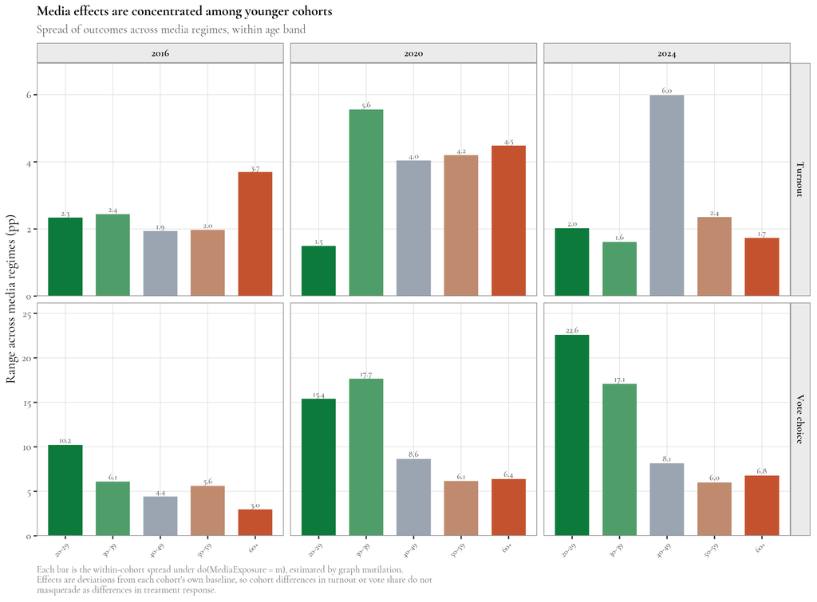

. . .

Ages 20–29: **10.2 → 15.4 → 22.6**

Ages 60+: 3.0 → 6.4 → 6.8

. . .

The gap is **widening**.

## What Media Competes Against

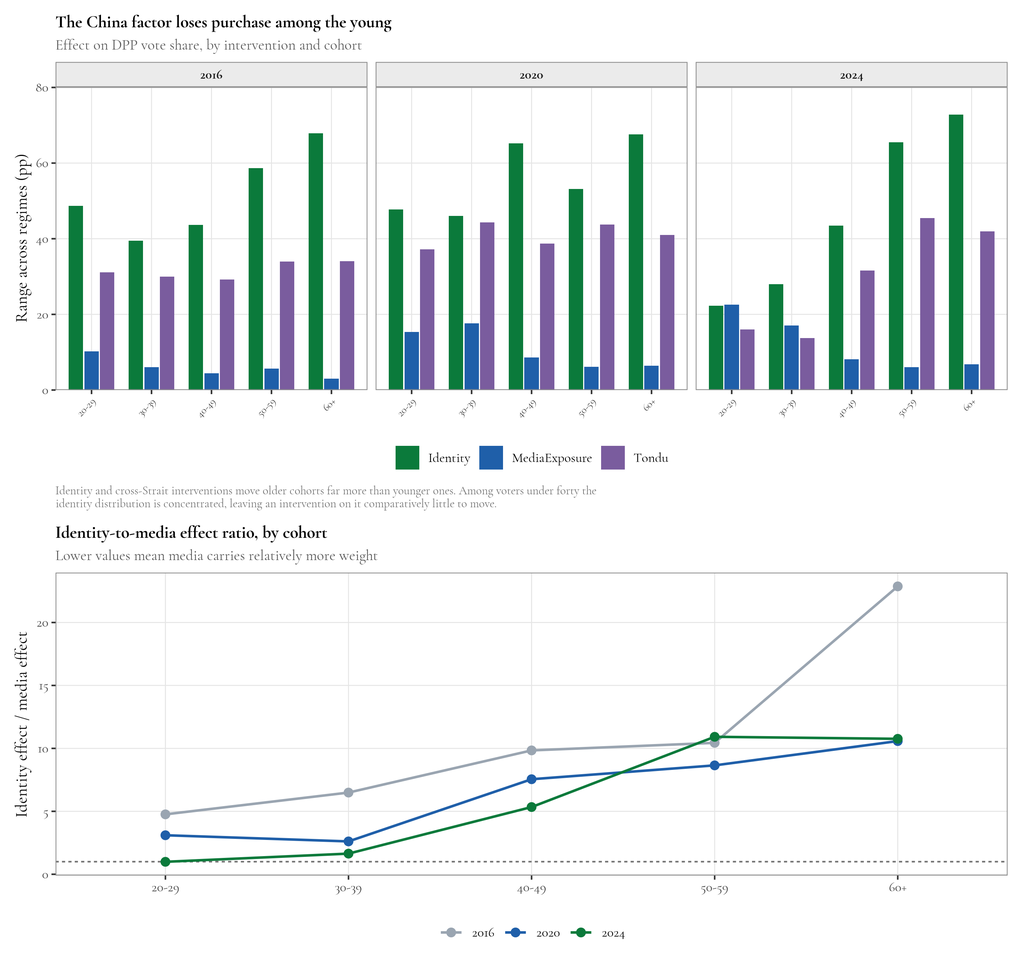

Identity-to-media ratio, ages 60+:

**22.9 → 10.6 → 10.8**

. . .

Ages 20–29:

**4.8 → 3.1 → 0.99**

. . .

In 2024 the two interventions move the youngest cohort by the **same amount**.

## The Number That Matters

**2024, voters aged 20–29:**

| Intervention | Effect on DPP share |
| --- | --- |
| National identity | 22.3 pp |
| **Media exposure** | **22.6 pp** |
| Cross-Strait position | 16.0 pp |

Television news moves these voters **as much as national identity does**.

Eight years earlier the ratio was 4.8 to 1.

## Is It Really Homogeneity?

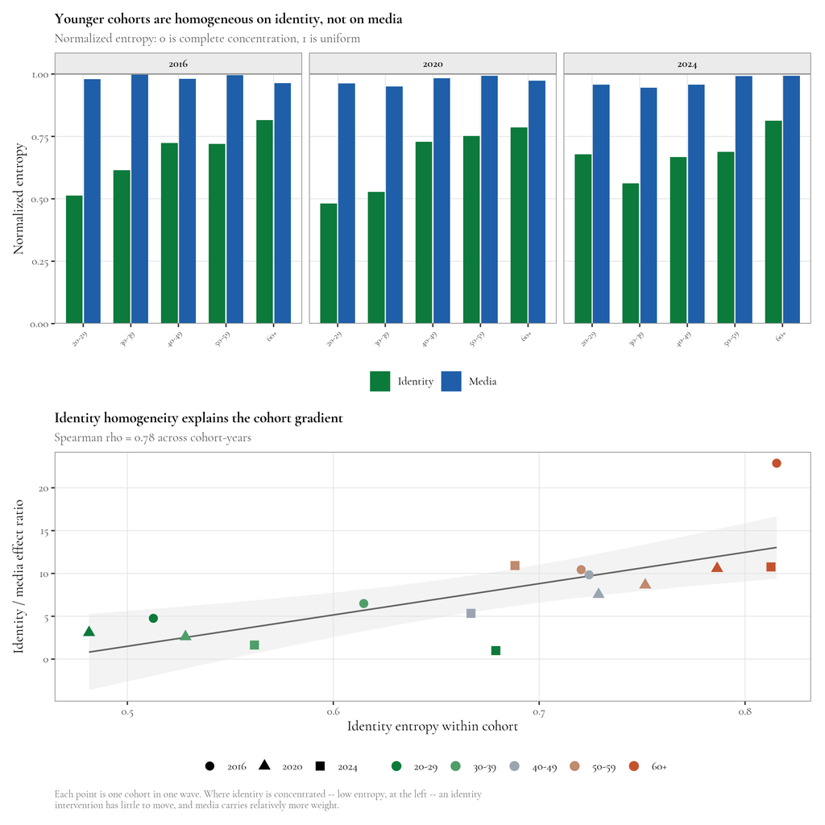

Identity entropy rises with age: **0.51 → 0.82**

Correlates at **0.78** with the identity/media ratio.

. . .

**Media entropy is flat** — 0.95 to 1.00 everywhere.

. . .

Young cohorts are homogeneous on identity **specifically**, not in general.

That is the discriminating evidence.

# The Cohort We Cannot Predict

## Unpredictable on Both Outcomes

**Vote choice:** full-model AUC **0.68–0.76** under 40, against **0.90–0.93** over 60.

Two-thirds of that gap survives adding identity, cross-Strait position, and media together.

**Turnout:** self-reported, inflated **13–20 points**, compressed against a ceiling.

Heterogeneous effects could not be estimated at all — the latent solution partitioned on turnout, not engagement.

**The cohort that matters most to the argument is the one we predict least well — on both quantities.**

## Why: Identity Stops Discriminating

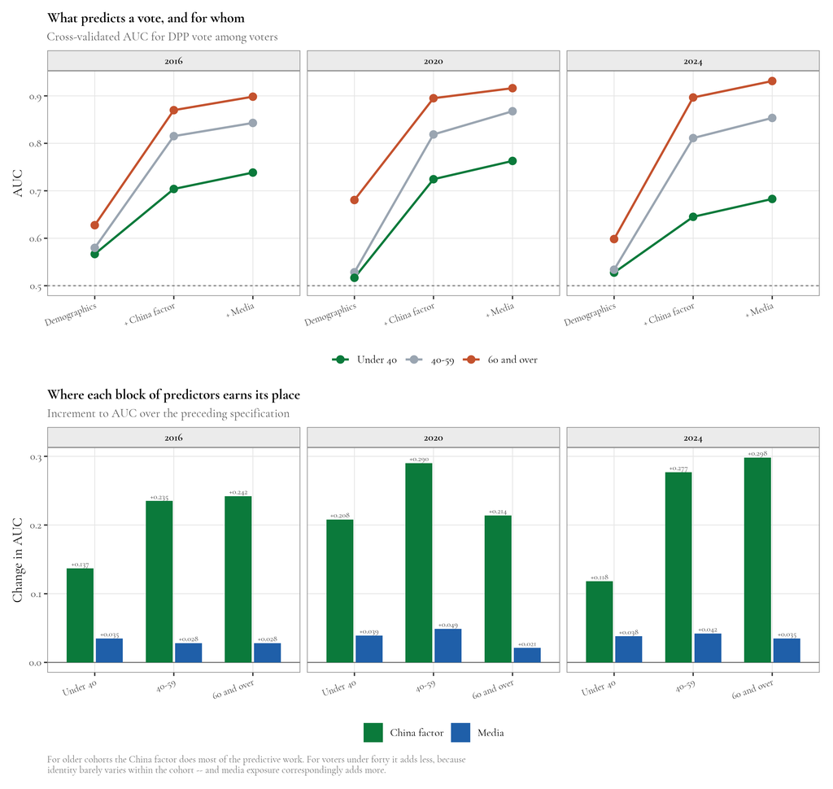

China factor adds **0.154** for the young, **0.251** for the old.

. . .

Media adds ~**0.03** — flat across all cohorts.

. . .

The gap narrows because identity does **less**, not because media does more.

. . .

Nothing we have replaces it.

## What the Synthetic Data Is Actually For

|  | Synthetic data |
| --- | --- |
| Marginals, joint distributions | reproduced almost exactly (TVD 0.001–0.016) |
| Individual prediction (AUC) | no contribution |

Not a tension. **The same finding from two directions.**

A **variance-reduction device for distributional quantities** — not an information-generation device for individual ones.

Augmentation gains were largest for the **largest** sample. We tested it against the wrong target.

# Would Better Data Help?

## Social Media: The Variance Argument Fails

**Only 2020 has the platform battery.** 2016 has none; 2024 has one generic item.

Media entropy among 20–29 is already **0.96–0.98**. TV exposure is *not* low-variance for them.

LINE and YouTube adoption is **near-universal** — a use-indicator would be near-constant in exactly the cohort needing discrimination.

Same failure mode as identity.

## Scraped Data Is Worse, Not Better

PTT posters, YouTube commenters, Facebook sharers are **not samples of users**.

They are the vocal minority — most engaged, most partisan, most willing to broadcast.

**A tail-weighted measure for a median-voter prediction problem.**

莊伯仲 warned of exactly this at the TPOC symposium: 同溫層偏誤.

And no platform carries age. Linkage runs through geography — back to the ecological problem.

## Aggregate Data Will Not Rescue Turnout

CEC publishes **registered voters** by age. That is the denominator.

**Turnout by age**: we could not confirm it is published.

So age-specific turnout is an *ecological inference* problem, not a retrieval one.

And EI is badly suited to age here: young-heavy districts **are** Taipei and Hsinchu; old-heavy districts **are** Yunlin and Pingtung.

Age composition is confounded with partisan geography.

## Where This Points

Every difficulty is about recovering **individual-level** information on young voters.

None obstructs **aggregate** estimation — and aggregates are what the synthetic data already reproduces well.

**Change the estimand.** DPP share within an age group, not the vote of a given respondent.

For forecasting and allocation that is the quantity actually wanted. It does not license claims about individual behaviour.

## Conclusion

**A closing cleavage does not just become less contested.** It loses its power to discriminate where closure is most complete.

Media effects among the young double: 10.2 → 22.6

Identity effects among the young **more than halve**: 48.7 → 22.3

Three qualifications: turnout shows no gradient; the mechanism weakens in 2024 (rho 0.6); the predictive payoff is small.

Three cross-sections give a **snapshot**, not a film. Cohort, period, and life cycle are not separable here.

## Thank You

**Karl Ho** — karlho@gmail.com

**John Marion Glendenning** — John.Glendenning@UTDallas.edu

###### Data: Taiwan’s Election and Democratization Study, 2016 · 2020 · 2024

# Additional Material

#### Slides below are held for discussion

## Silicon Samples Are Already Commercial

**TPOC 台灣議題研究中心**, August 2026:

- 3,000 AI agents, 28 attributes, 26 years of polling data
- Benchmarked against Meilidao and TVBS phone polls
- **Average error: 4.56 percentage points**
- Subscription launched September — NT$100 per question

## Three Warnings From That Room

**Variance compression.** NTU’s 馮勃翰: AI answers cluster in middle options. *Bisbee, replicated in Taiwan.*

**Echo-chamber bias.** 莊伯仲: feeding agents social media produces 同溫層偏誤.

**Ecological fallacy.** UT Austin’s 林澤民: AI agents are prone to it.

**Bayesian calibration.** 謝邦昌: hybrid human-agent designs will require it.

## Turnout Is Not Vote Choice

Rank correlation of media effect with age:

**Vote choice:** −0.9, −0.8, −0.9

**Turnout:** +0.2, +0.4, +0.1

Turnout effects are small — 1.5 to 6.0 points against 3.0 to 22.6.

Self-reported turnout runs far above official. We read this as **uninformative**, not null.

## Does Synthetic Augmentation Help?

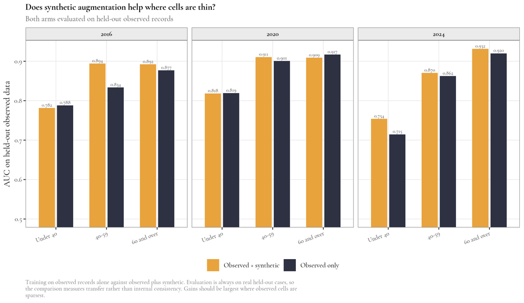

**It does not.**

Mean gain: 40–59 = **+0.026**, under 40 = **+0.011**, 60+ = **+0.006**.

. . .

The largest gain goes to the **largest** sample — backwards from the sparsity story.

. . .

Two of three under-40 gains are ≈ 0.

## The Methodological Point

Zaller predicts heterogeneity in media effects by **political awareness**.

This suggests a complementary axis: heterogeneity by **how much room the organizing variable has left to move** within a subgroup.

Effect heterogeneity should be estimated with respect to the distribution of the dominant cleavage — not assumed uniform.

## The Measurement Caveat

Our media variable is **television-only** — what TEDS supports consistently across all three waves.

This understates young-voter exposure specifically. LINE, PTT, and Dcard carry political content the instrument does not capture.

The rising “None” category among the young means **absence of television news**, not absence of political information.

**This works against the hypothesis.** If young voters get partisan content through unobserved channels and we still recover larger television effects, the true asymmetry is larger.

## Media Diet by Cohort

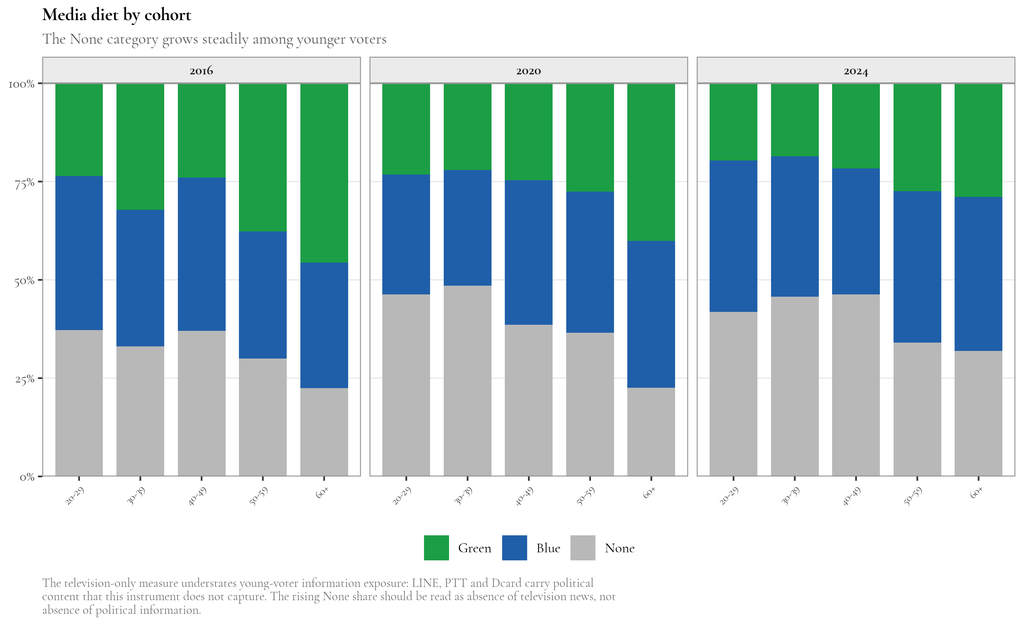

## Why Bayesian Networks, Not Silicon Samples

**Argyle et al. (2023):** condition an LLM on a demographic backstory. Tetrachoric correlations above 0.9.

**Bisbee et al. (2024):** compressed variance, 48% of coefficients differ significantly, prompt sensitivity, temporal instability, demand effects.

**Santurkar et al. (2023):** LLMs reflect liberal, educated, Western opinion.

The deeper problem: none of those failures is **diagnosable from inside the method**.

## One Quantity, Two Approaches

$$P(\text{DPP vote} \mid \text{Age} = 20\text{–}29, \text{Media} = \text{Green})$$

**Silicon sample:** write a prompt, sample, tabulate. Traceable to nothing.

**Bayesian network:** read from a conditional probability table fitted to TEDS respondents in that cell.

Inspectable. Cell count checkable. Provenance stateable.

## Why Latent Class Analysis First

| Specification | Configurations | Free parameters |
| --- | --- | --- |
| No latent segment | 6,480 | 19,440 |
| Latent segment, k = 6 | 324 | 972 |

Wave n is in the low thousands. **Twenty-fold reduction.**

It does not create information. It imposes a constraint — all demographic variation acts on vote choice *through* the segment.

## Media Coding: Alignment Moves

**Huang (2009)** codes Eastern Television and Era as **pan-Blue** for 2008.

**2020 audience rankings** place both on the **pan-Green** side.

No single time-invariant coding is right for all three waves.

We withhold partisan classification from every contested outlet — which **attenuates** the estimated effect toward zero.

The error runs against our own conclusion.

## Cohort Versus Period

Three cross-sections cannot separate the two.

Is the pattern fixed at socialization, or do individuals become less media-responsive as they age?

TEDS panel components would support a dynamic specification. This is the first item in future research.

## Future Research

- **Platform-specific measurement** — LINE, PTT, Dcard for the waves where available
- **Cohort versus period** — dynamic Bayesian networks on the panel component
- **The third-force channel** — model “Other” as substantive, not residual
- **Extend backward** — 2008 and 2012 waves to test whether the pattern tracks the progressive closure of the cleavage

## References

- Achen, C.H. and T.Y. Wang, eds. 2017. *The Taiwan Voter*. University of Michigan Press.
- Argyle, L.P. et al. 2023. Out of one, many. *Political Analysis* 31: 337–351.
- Bisbee, J. et al. 2024. Synthetic replacements for human survey data? *Political Analysis* 32: 401–416.
- Ho, K. and J.M. Glendenning. 2026. Media Effects and Party Support Volatility in US. SPSA.
- Huang, C.-L. 2009. The Changing Roles of the Media in Taiwan’s Democratization Process. Brookings.
- Linzer, D.A. and J.B. Lewis. 2011. poLCA. *Journal of Statistical Software* 42.
- Pearl, J. 2009. *Causality*, 2nd ed. Cambridge University Press.
- Santurkar, S. et al. 2023. Whose opinions do language models reflect? *ICML*.
- Scutari, M. 2010. Learning Bayesian networks with bnlearn. *JSS* 35.
- Zaller, J.R. 1992. *The Nature and Origins of Mass Opinion*. Cambridge University Press.